# Curs de manipulació de dades en R

24 de juliol de 2025

## Regressió logística

La fem servir quan la variable dependent és dicotòmica:

\[\phantom{aa} Y = \frac{1}{1+e^{-(\beta_o+\beta_1X+\epsilon)}}\]

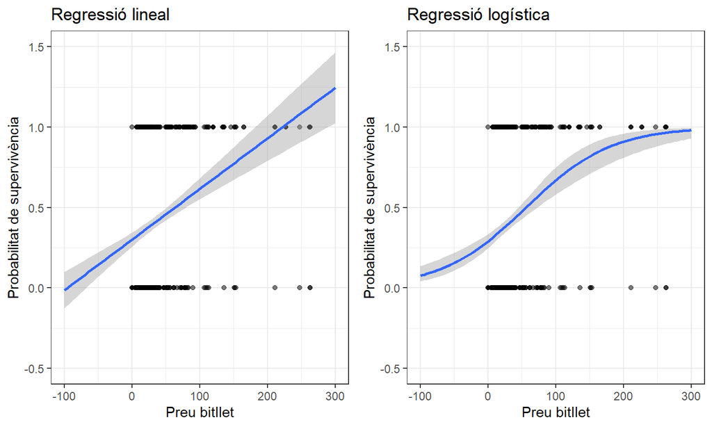

## Interpretació dels gràfics de regressió logística

**Gràfic dreta**: Només regressió logística. La corba es manté sempre entre 0 i 1, que és el que volem per probabilitats.

## Regressió logística univariant

```r
# Regressió logística univariant amb tidymodels
library(tidymodels)
log_reg_spec <- logistic_reg() |>
  set_engine("glm")

model4 <- workflow() |>
  add_formula(Survived ~ Fare) |>
  add_model(log_reg_spec) |>
  fit(data = titanic_data)

tidy(model4)
```

```
## # A tibble: 2 × 5
##   term        estimate std.error statistic  p.value
##   <chr>          <dbl>     <dbl>     <dbl>    <dbl>
## 1 (Intercept)  -0.897    0.108       -8.33 7.84e-17
## 2 Fare          0.0160   0.00250      6.39 1.61e-10
```

## Regressió logística multivariant

```r
# Regressió logística multivariant amb tidymodels
log_reg_spec <- logistic_reg() |> set_engine("glm")

model4 <- workflow() |>
  add_formula(Survived ~ Fare + Age + Sex) |>
  add_model(log_reg_spec) |>
  fit(data = titanic_data)

tidy(model4)
```

```
## # A tibble: 4 × 5
##   term        estimate std.error statistic  p.value
##   <chr>          <dbl>     <dbl>     <dbl>    <dbl>
## 1 (Intercept)   0.935    0.239        3.91 9.24e- 5
## 2 Fare          0.0128   0.00270      4.74 2.16e- 6
## 3 Age          -0.0106   0.00650     -1.63 1.04e- 1
## 4 Sexmale      -2.35     0.190      -12.4  4.37e-35
```

## Com de bé ho hem fet?

```r
# Entrenem el model amb tidymodels
library(tidymodels)
log_reg_spec <- logistic_reg() |> set_engine("glm")

logistic_workflow <- workflow() |>
  add_formula(Survived ~ Fare + Age + Sex) |>
  add_model(log_reg_spec)

logistic_fit <- logistic_workflow |>
  fit(data = train_data)

# Fem prediccions al test set
predictions_prob <- predict(logistic_fit, new_data = test_data, type = "prob")$.pred_Sí
predictions_class <- factor(if_else(predictions_prob > 0.5, "Sí", "No"), levels = c("No", "Sí"))

# Matriu de confusió per la regressió logística
logistic_conf_matrix <- confusionMatrix(predictions_class, test_data$Survived, positive = "Sí")
```

## Avaluació del model

```r
library(caret)
confusionMatrix(
  predictions_class,
  test_data$Survived,
  positive = "Sí",
  mode = "everything"
  )
```

## Avaluació del model

```
## Confusion Matrix and Statistics
##
##           Reference
## Prediction  No  Sí
##         No 194   0
##         Sí  16 121
##
##                Accuracy : 0.9517
##                  95% CI : (0.9227, 0.9721)
##     No Information Rate : 0.6344
##     P-Value [Acc > NIR] : < 2.2e-16
##
##                   Kappa : 0.8986
##
##  Mcnemar's Test P-Value : 0.0001768
##
##             Sensitivity : 1.0000
##             Specificity : 0.9238
##          Pos Pred Value : 0.8832
##          Neg Pred Value : 1.0000
##               Precision : 0.8832
##                  Recall : 1.0000
##                      F1 : 0.9380
##              Prevalence : 0.3656
##          Detection Rate : 0.3656
##    Detection Prevalence : 0.4139
##       Balanced Accuracy : 0.9619
##
##        'Positive' Class : Sí
##
```

## Interpretació de les mètriques

- **Accuracy**: Proporció total de prediccions correctes
- **Sensitivity (Recall)**: Proporció de supervivents reals que hem predit correctament
- **Specificity**: Proporció de no-supervivents reals que hem predit correctament
- **Precision**: Proporció de prediccions de supervivència que són correctes
- **F1-Score**: Mitjana harmònica entre precision i recall (bona per classes desbalancejades)

## Random Forest

## Què és?

Random Forest és un mètode d’ensemble que combina múltiples arbres de decisió per millorar la precisió i reduir l’overfitting.

Avantatges:

- Menys propens a overfitting que arbres individuals
- No requereix normalització de dades
- Proporciona importància de variables

Desavantatges:

- S’han d’ajustar diversos hiperparàmetres
- Una mica lent d’entrenar
- Difícil d’interpretar

## Preparació de les dades

```r
# Preparació de les dades per Random Forest
train_rf <- train_data |>
  select(Survived, Age, Fare, Sex, Pclass) |>
  mutate(across(where(is.character), as.factor)) |>
  drop_na()

# Preparació de les dades de test per Random Forest
test_rf <- test_data |>
  select(Survived, Age, Fare, Sex, Pclass) |>
  mutate(across(where(is.character), as.factor)) |>
  drop_na()
```

## Entrenament del model

```r
library(tidymodels)
# Definim el model Random Forest amb tidymodels
rf_spec <- rand_forest(
  mtry = 3,
  trees = 500,
  min_n = 5
) |>
  set_engine("ranger", importance = "impurity") |>
  set_mode("classification")

# Creem el workflow
rf_workflow <- workflow() |>
  add_formula(Survived ~ .) |>
  add_model(rf_spec)

# Entrenem el model
rf_fit <- rf_workflow |>
  fit(data = train_rf)
```

## Prediccions i avaluació

```r
# Prediccions
rf_predictions <- rf_fit |>
  predict(test_rf, type = "class")

# Avaluació
rf_conf_matrix <- confusionMatrix(
  rf_predictions$.pred_class,
  test_rf$Survived,
  positive = "Sí"
)
print(glue("Random Forest Accuracy: {rf_conf_matrix$overall['Accuracy']}"))
```

```
## Random Forest Accuracy: 0.851963746223565
```

## Importància de variables

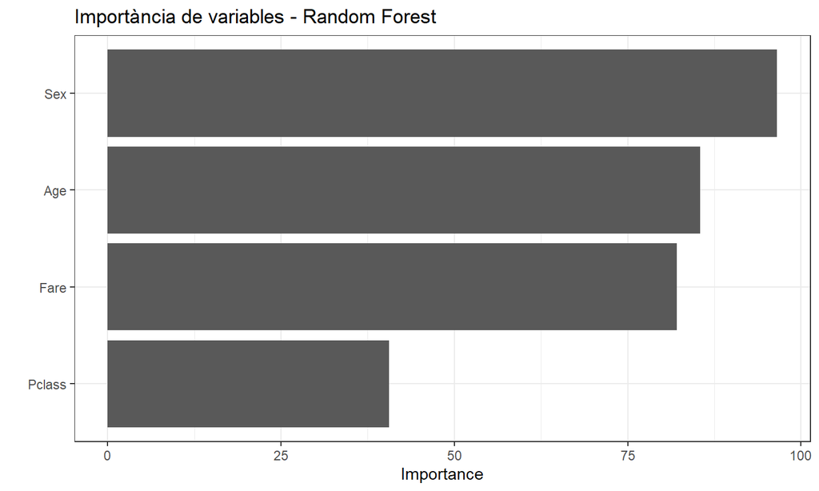

```r
library(vip)

vip(rf_fit, num_features = 10) +
  labs(title = "Importància de variables - Random Forest")
```

## XGBoost (Gradient Boosting)

## Què és?

XGBoost és un algorisme de gradient boosting optimitzat que construeix seqüencialment models febles per crear un model fort.

Avantatges:

- Inclou regularització per evitar overfitting
- Excel·lent rendiment en competicions de machine learning

Desavantatges:

- S’han d’ajustar diversos hiperparàmetres
- Molt lent d’entrenar
- Difícil d’interpretar

## Preparació de les dades

```r
# Preparació de les dades per XGBoost amb tidymodels
train_xgb <- train_data |>
  select(Survived, Age, Fare, Sex, Pclass) |>
  mutate(Survived = as.factor(Survived)) |>
  drop_na()

test_xgb <- test_data |>
  select(Survived, Age, Fare, Sex, Pclass) |>
  mutate(Survived = as.factor(Survived)) |>
  drop_na()
```

## Creació del model i preprocessament

```r
# Definim el model XGBoost
xgb_spec <- boost_tree(
  trees = 100,
  tree_depth = 3,
  min_n = 5,
  loss_reduction = 0,
  sample_size = 1,
  mtry = 3
) |>
  set_engine("xgboost") |>
  set_mode("classification")

# Creem el workflow amb preprocessament automàtic
xgb_workflow <- workflow() |>
  add_formula(Survived ~ .) |>
  add_model(xgb_spec)
```

## Entrenament del model

```r
# Entrenem el model
xgb_fit <- xgb_workflow |>
  fit(data = train_xgb)
```

## Prediccions i avaluació

```r
# Prediccions
xgb_predictions <- xgb_fit |>
  predict(test_xgb, type = "class")

# Avaluació
xgb_conf_matrix <- confusionMatrix(
  xgb_predictions$.pred_class,
  test_xgb$Survived,
  positive = "Sí"
)
print(glue("XGBoost Accuracy: {xgb_conf_matrix$overall['Accuracy']}"))
```

```
## XGBoost Accuracy: 0.873111782477341
```

## Importància de variables

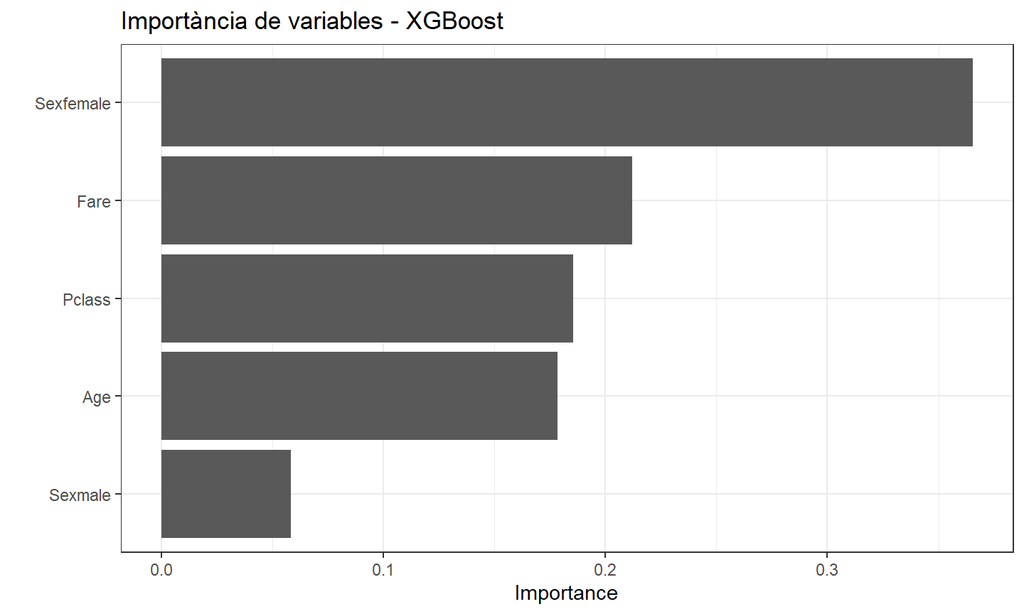

```r
library(vip)
vip(xgb_fit, num_features = 10) +
  labs(title = "Importància de variables - XGBoost")
```

## Comparació de models

Comparació de mètriques entre models

| Model | Accuracy | F1-score |
| --- | --- | --- |
| Regressió Logística | 0.952 | 0.938 |
| Random Forest | 0.852 | 0.800 |
| XGBoost | 0.873 | 0.829 |

## Interpretació

- **Regressió Logística**: Model lineal simple, fàcil d’interpretar
- **Random Forest**: Model no lineal, robust i estable
- **XGBoost**: Model avançat, sovint amb millor rendiment

## Resum

| Independent \ Dependent | Categòrica | Contínua |
| --- | --- | --- |
| Categòrica | \(\chi^2\); Test de Fisher | Test T; U de Mann Whitney; ANOVA |
| Contínua | Regressió logística | Correlació; regressió lineal |